# Lion in the Room

### Loading the necessary packages for the project

```r
library(tidyverse)  # Loads ggplot2, dplyr, tidyr, readr, purrr, tibble, and stringr
library(readxl)     # For reading Excel files
library(rvest)      # For web scraping
library(httr)       # For working with HTTP
library(rcrossref)  # For using CrossRef's API
library(janitor)    # For cleaning data
library(reshape2)   # For reshaping data
library(igraph)     # For graphing
library(ggraph)     # For graphing
library(scales)     # For graphing
library(lubridate)  # For time series work
library(gridExtra)  # For Grid making
library(VennDiagram)# For Venn Diagrams
```

### Loading the data-set sourced from Retraction Watch on 12-Jan-2024

```r
data<- read.csv("retraction_watch.csv")
abdc<- read.csv("abdc.csv")
predatory<- read.csv("predatory.csv")
```

### Doing some wrangling of the data

```r
# Convert dates to POSIX format for the pupose of computation
data$OriginalPaperDate <- as.POSIXct(data$OriginalPaperDate, format = "%m/%d/%Y %H:%M")
data$RetractionDate <- as.POSIXct(data$RetractionDate, format = "%m/%d/%Y %H:%M")

# Compute the difference in months
data$DurationInMonths <- interval(start = data$OriginalPaperDate, end = data$RetractionDate) / months(1)

# Extract year from RetractionDate
data$RetractionYear <- year(data$RetractionDate)

#Creating Clean names
data<- data %>%
  clean_names()

abdc<- abdc%>%
  clean_names()

predatory<- predatory %>%
  clean_names()
```

### Creating the lists

```r
abdc_list <- unique(tolower(abdc$journal))
retraction_list <- unique(tolower(data$journal))
predatory_list <- unique(tolower(predatory$journal))
```

### Trying to create a venn diagram to see how these sets intersect

```r
# Define a list of lists for the Venn diagram
list_of_lists <- list(
  ABDC = abdc_list,
  Retraction = retraction_list,
  Predatory = predatory_list
)

# Specify the filename for the output
output_filename <- "venn_diagram.png"

# Create and save the Venn diagram
venn.plot <- venn.diagram(
  x = list_of_lists,
  category.names = c("ABDC", "Retraction", "Predatory"),
  filename = output_filename
)
```

## Filter data for rows where article_type is “Research Article” or “Article in Press”

```r
# This is to ensure that there are no conference papers, book chapters, and others that are there in the dataset. Our research is limited to journal publications only.
filtered_data <- data[grepl("Research Article", data$article_type) | grepl("Article in Press", data$article_type), ]
```

## Looking only at the intersection of ABDC and Retracted.

```r
ret_int_abdc <- filtered_data %>%
  filter(
    tolower(filtered_data$journal) %in% tolower(abdc$journal) # Converting to lower case to ensure that case mismatches do not case issues in matching
  )

write.csv(ret_int_abdc, "ret_int_abdc.csv") # This is so that Pari can see the data
```

There are 951 data points with the conference articles, and 883 without the conference and other types of articles. It is these 883 articles that we focus our attention on.

## Let’s just describe this dataset. This is for us to mention in the introduction section

```r
# Select the specified columns
our_interest <- select(ret_int_abdc, record_id, subject, title, original_paper_date, reason, author)
```

## Plot Average Number of Subjects per Paper Over Time, and the number of retracted artciles in the ABDC

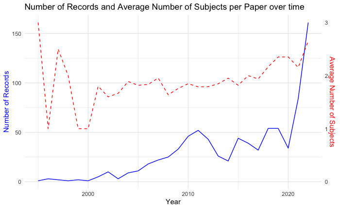

```r
# Calculate the number of subjects per record
our_interest$subject_count <- sapply(strsplit(our_interest$subject, ";"), function(x) sum(nzchar(x)))

# Extract the year from the original paper date
our_interest$year <- format(our_interest$original_paper_date, "%Y")

# Ensure year is treated as a continuous variable
our_interest$year <- as.numeric(our_interest$year)

# Create a summary data frame
yearly_summary <- our_interest %>%
  group_by(year) %>%
  summarize(
    record_count = n(),
    avg_subject_count = mean(subject_count, na.rm = TRUE)
  ) %>%
  ungroup()

# Ensure we have a row for every year in the range from 2000 to 2022
yearly_summary <- data.frame(year = 1995:2022) %>%
  left_join(yearly_summary, by = "year") %>%
  replace_na(list(record_count = 0, avg_subject_count = 0))

# Find the maximums for scaling the secondary axis
max_records <- max(yearly_summary$record_count)
max_avg_subjects <- max(yearly_summary$avg_subject_count)

# Create the line plot with two y-axes and colored axis labels
ggplot(yearly_summary, aes(x = year)) +
  geom_line(aes(y = record_count), color = "blue") +
  labs(x = "Year", y = "Number of Records", title = "Number of Records and Average Number of Subjects per Paper over time") +
  theme_minimal() +
  theme(axis.title.y = element_text(color = "blue")) +
  scale_y_continuous(
    "Number of Records",
    sec.axis = sec_axis(~ . * max_avg_subjects / max_records, name = "Average Number of Subjects", labels = scales::comma)
  ) +
  geom_line(aes(y = avg_subject_count * max_records / max_avg_subjects), color = "red", linetype = "dashed") +
  theme(axis.title.y.right = element_text(color = "red"))
```

## Checking if the same trend also appears in the metasubject realm

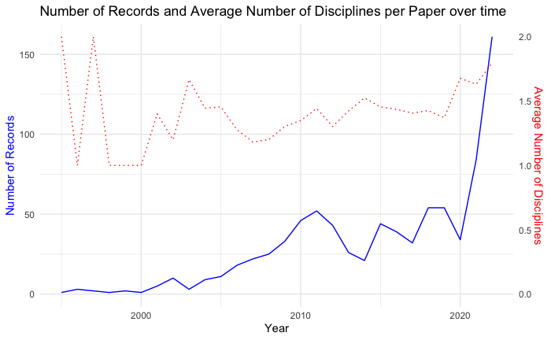

```r
# Define the mapping of codes to metasubjects
metasubjects_map <- c(
  "B/T" = "Business and Technology",
  "BLS" = "Basic Life Sciences",
  "ENV" = "Environmental Sciences",
  "HSC" = "Health Sciences",
  "HUM" = "Humanities",
  "PHY" = "Physical Sciences",
  "SOC" = "Social Sciences"
)

# Extract and map metasubjects
our_interest <- our_interest %>%
  mutate(
    year = as.numeric(format(original_paper_date, "%Y")),
    metasubject_codes = str_extract_all(subject, "\\(\\w+/\\w+\\)|\\(\\w+\\)"),
    metasubjects = lapply(metasubject_codes, function(codes) {
      unique_codes <- unique(codes)
      sapply(unique_codes, function(code) metasubjects_map[substr(code, 2, nchar(code) - 1)])
    }),
    metasubject_count = sapply(metasubjects, length)
  )

# Create a summary data frame for metasubjects
yearly_metasubject_summary <- our_interest %>%
  group_by(year) %>%
  summarize(
    avg_metasubject_count = mean(metasubject_count, na.rm = TRUE),
    record_count = n()  # Assuming you want to also plot the number of records
  ) %>%
  ungroup()

# Ensure we have a row for every year in the range
yearly_metasubject_summary <- data.frame(year = 1995:2022) %>%
  left_join(yearly_metasubject_summary, by = "year") %>%
  replace_na(list(avg_metasubject_count = 0, record_count = 0))
# Find the maximum value to set as the upper limit for both y-axes
max_count <- max(yearly_metasubject_summary$record_count, na.rm = TRUE)
max_avg_metasubjects <- max(yearly_metasubject_summary$avg_metasubject_count, na.rm = TRUE)
common_limit <- max(max_count, max_avg_metasubjects)

# Find the maximum value to use as the upper limit for the secondary y-axis
max_records <- max(yearly_metasubject_summary$record_count, na.rm = TRUE)
max_avg_metasubjects <- max(yearly_metasubject_summary$avg_metasubject_count, na.rm = TRUE)

# Create the line plot with adjusted axis scales
ggplot(yearly_metasubject_summary, aes(x = year)) +
  geom_line(aes(y = record_count), color = "blue") + # Plot number of records in blue
  labs(x = "Year", y = "Number of Records", title = "Number of Records and Average Number of Disciplines per Paper over time") +
  theme_minimal() +
  theme(
    axis.title.y = element_text(color = "blue"),
    axis.title.y.right = element_text(color = "red")
  ) +
  scale_y_continuous(
    name = "Number of Records",
    limits = c(0, max_records), # Set limits for the primary y-axis
    sec.axis = sec_axis(~ . * max_avg_metasubjects / max_records, name = "Average Number of Disciplines", labels = scales::comma)
  ) +
  geom_line(aes(y = avg_metasubject_count * max_records / max_avg_metasubjects), color = "red", linetype = "dotted") + # Plot avg metasubjects in red
  scale_x_continuous(limits = c(1995, 2022)) # Set x-axis limits from 1980 to 2022
```

The trend here also appears somewhat consistent with the subjects. This means that retracted papers are slowly becoming inter disciplinary in nature.

## Now, ww create a correlation plot to see which Disciplines keep occuring together. I am not doing the regular subjects becasue that would be too cluttered in my opinion.

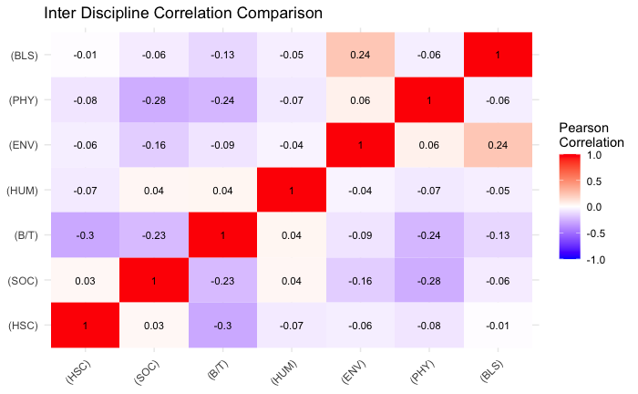

```r
# Extract meta-subjects from the 'subject' column
our_interest$meta_subjects <- str_extract_all(our_interest$subject, "\\(.*?\\)")

# Create a unique list of all meta-subjects
all_meta_subjects <- unique(unlist(our_interest$meta_subjects))

# Function to create dummy variables
create_dummy <- function(meta_subjects, subject) {
  as.integer(subject %in% meta_subjects)
}

# Apply the function to create dummy variables for each meta-subject
for (meta_subject in all_meta_subjects) {
  our_interest[[meta_subject]] <- sapply(our_interest$meta_subjects, create_dummy, subject = meta_subject)
}

# Select only the meta-subject dummy variables
meta_subject_cols <- all_meta_subjects

# Calculate the correlation matrix
cor_matrix <- cor(our_interest[, meta_subject_cols], use = "complete.obs")


# Melt the correlation matrix for visualization
melted_cor_matrix <- melt(cor_matrix)

# Plot the correlation matrix
ggplot(data = melted_cor_matrix, aes(x = Var1, y = Var2, fill = value)) +
  geom_tile() +
  geom_text(aes(label = round(value, 2)), color = "black", size = 3) +
  scale_fill_gradient2(low = "blue", high = "red", mid = "white",
                       midpoint = 0, limit = c(-1, 1), space = "Lab",
                       name = "Pearson\nCorrelation") +
  theme_minimal() +
  theme(axis.text.x = element_text(angle = 45, hjust = 1),
        axis.title = element_blank()) + ggtitle("Inter Discipline Correlation Comparison")
```

This is the key for the reference of others: (B/T): Business and Technology (BLS): Basic Life Sciences (ENV): Environmental Sciences (HSC): Health Sciences (HUM):Humanities (PHY): Physical Sciences (SOC): Social Sciences

This investigation reveals that there are no two subjects that are strongly correlated. However, we can try something interesting here.

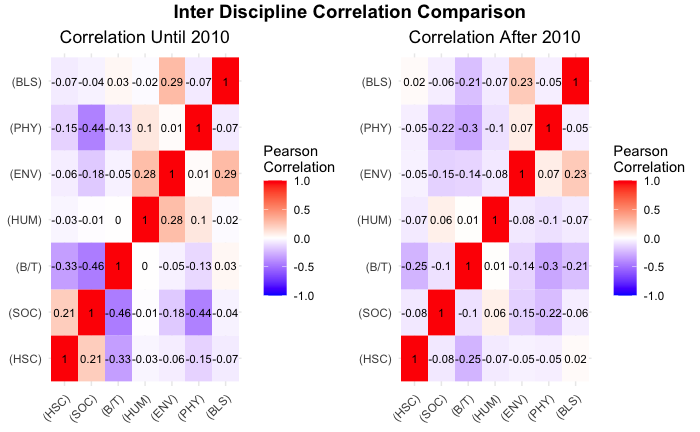

```r
library(dplyr)
library(ggplot2)
library(stringr)
library(reshape2)
library(gridExtra) # This library is used to arrange ggplots side by side

# Extract meta-subjects from the 'subject' column
our_interest$meta_subjects <- str_extract_all(our_interest$subject, "\\(.*?\\)")

# Create a unique list of all meta-subjects
all_meta_subjects <- unique(unlist(our_interest$meta_subjects))

# Function to create dummy variables
create_dummy <- function(meta_subjects, subject) {
  as.integer(subject %in% meta_subjects)
}

# Apply the function to create dummy variables for each meta-subject
for (meta_subject in all_meta_subjects) {
  our_interest[[meta_subject]] <- sapply(our_interest$meta_subjects, create_dummy, subject = meta_subject)
}

# Filter data for the two periods
data_until_2010 <- our_interest %>% filter(year <= 2010)
data_after_2010 <- our_interest %>% filter(year > 2010)

# Select only the meta-subject dummy variables for correlation calculation
meta_subject_cols <- all_meta_subjects

# Calculate the correlation matrix for both periods
cor_matrix_until_2010 <- cor(data_until_2010[, meta_subject_cols], use = "complete.obs")
cor_matrix_after_2010 <- cor(data_after_2010[, meta_subject_cols], use = "complete.obs")

# Melt the correlation matrices for visualization
melted_cor_matrix_until_2010 <- melt(cor_matrix_until_2010)
melted_cor_matrix_after_2010 <- melt(cor_matrix_after_2010)

# Function to create a ggplot of the correlation matrix
create_cor_plot <- function(melted_cor_matrix) {
  ggplot(data = melted_cor_matrix, aes(x = Var1, y = Var2, fill = value)) +
    geom_tile() +
    geom_text(aes(label = round(value, 2)), color = "black", size = 3) +
    scale_fill_gradient2(low = "blue", high = "red", mid = "white",
                         midpoint = 0, limits = c(-1, 1), space = "Lab",
                         name = "Pearson\nCorrelation") +
    theme_minimal() +
    theme(axis.text.x = element_text(angle = 45, hjust = 1),
          axis.title = element_blank())
}

# Create the plots
plot_until_2010 <- create_cor_plot(melted_cor_matrix_until_2010)
plot_after_2010 <- create_cor_plot(melted_cor_matrix_after_2010)

library(gridExtra)

# Add individual titles to each plot
plot_until_2010 <- plot_until_2010 + ggtitle("Correlation Until 2010") + theme(plot.title = element_text(hjust = 0.5))
plot_after_2010 <- plot_after_2010 + ggtitle("Correlation After 2010") + theme(plot.title = element_text(hjust = 0.5))

# Combine the plots side by side with a common title
grid.arrange(plot_until_2010, plot_after_2010, ncol = 2,
             top = textGrob("Inter Discipline Correlation Comparison", gp = gpar(fontface = "bold", fontsize = 14)))
```

```r
NA
NA
```

This shows that there has not really been any significant trend. If anything, the correlation has dropped over time.

This points to the fact that there this issue is not particularly limited to some areas - but much more rampant.

In fact, if we start looking at the titles of the papers, we begin to get a much better picture.

## Create a Word Map from the ‘Title’ Variable

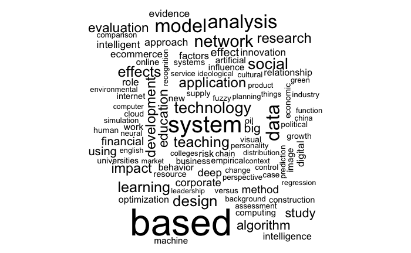

```r
library(wordcloud)
library(tm)

# Create a text corpus
corpus = Corpus(VectorSource(our_interest$title))

# Clean up the text
corpus = tm_map(corpus, content_transformer(tolower))
corpus = tm_map(corpus, removePunctuation)
corpus = tm_map(corpus, removeNumbers)
corpus = tm_map(corpus, removeWords, stopwords("english"))
# Create a word cloud
wordcloud(corpus, max.words = 100)
```

Well, we have to speak about this team!

Let me just find out if there is some correlation between the reasons that are cited for retraction

[figure not shown]

```r
# Step 1: Split the 'reason' field into individual reasons and remove the '+' prefix
reasons_list <- strsplit(gsub("^\\+", "", our_interest$reason), ";")

# Step 2: Identify unique reasons
unique_reasons <- unique(unlist(reasons_list))

# Step 3: Create dummy variables for each unique reason
for(reason in unique_reasons) {
  our_interest[[reason]] <- sapply(reasons_list, function(x) as.integer(reason %in% x))
}

# Select only dummy variables (and any other numeric variables you want to include)
numeric_data <- our_interest[, sapply(our_interest, is.numeric)]

# Compute the correlation matrix for numeric data
cor_matrix <- cor(numeric_data)

# Melt the correlation matrix for visualization
melted_cor_matrix <- reshape2::melt(cor_matrix)

# Define a threshold for displaying text
threshold <- 0.5

# Plot the correlation matrix
ggplot(data = melted_cor_matrix, aes(x=Var1, y=Var2, fill=value)) +
    geom_tile() +
    geom_text(aes(label = ifelse(abs(value) > threshold, round(value, 2), '')), color = "black", size = 2.5) +
    scale_fill_gradient2(low = "blue", high = "red", mid = "white",
                         midpoint = 0, limit = c(-1,1), space = "Lab",
                         name="Pearson\nCorrelation") +
    theme_minimal() +
    theme(axis.text.x = element_text(angle = 45, hjust = 1, size = 4),
          axis.text.y = element_text(size = 6),
          axis.title = element_blank()) +
    coord_fixed() # Ensure square cells
```

This looks a little difficult to comprehend.I am going to map them to something more easy to understand and check again.

## Creating broader themes.

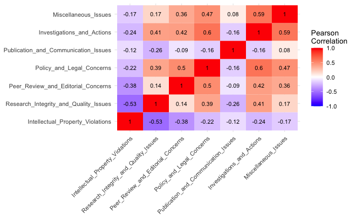

```r
# Define the patterns for each category
patterns <- list(
  Intellectual_Property_Violations = c("Plagiarism", "Duplication", "Euphemisms for Plagiarism", "False/Forged Authorship"),
  Research_Integrity_and_Quality_Issues = c("Not Reproducible", "Unreliable Results", "Error in Text", "Error in Analyses", "Error in Methods", "Error in Data", "Error in Results", "Fabrication", "Falsification", "Ethical Violations", "Issues About Data"),
  Peer_Review_and_Editorial_Concerns = c("Fake Peer Review", "Rogue Editor", "Investigation by Journal/Publisher", "Error by Journal/Publisher", "Objections by Author"),
  Policy_and_Legal_Concerns = c("Breach of Policy", "Issues about Referencing", "Legal Reasons", "Lack of Approval"),
  Publication_and_Communication_Issues = c("Withdrawal", "Limited or No Information", "Notice - Lack of", "Author Unresponsive", "Update of Prior Notice"),
  Investigations_and_Actions = c("Investigation by Third Party", "Doing the Right Thing"),
  Miscellaneous_Issues = c("Date of Retraction", "Randomly Generated Content", "Original Data not Provided", "Concerns About Image")
)

# Function to create dummy variables for categories based on the presence of certain patterns
create_dummy_vars <- function(df, patterns) {
  for (category in names(patterns)) {
    pattern <- patterns[[category]]
    df[[category]] <- as.integer(sapply(df$reason, function(x) {
      any(sapply(pattern, function(y) str_detect(x, regex(y, ignore_case = TRUE))))
    }))
  }
  return(df)
}

# Apply the function to the data frame
our_interest <- create_dummy_vars(our_interest, patterns)

# Ensure these columns exist in your our_interest dataframe
selected_columns <- c("Intellectual_Property_Violations", "Research_Integrity_and_Quality_Issues",
                      "Peer_Review_and_Editorial_Concerns", "Policy_and_Legal_Concerns",
                      "Publication_and_Communication_Issues", "Investigations_and_Actions",
                      "Miscellaneous_Issues")

# Check if all selected columns are present in our_interest
if(all(selected_columns %in% names(our_interest))) {
    # Select only the specified dummy variable columns
    dummy_data <- our_interest[, selected_columns]

    # Calculate the correlation matrix
    cor_matrix <- cor(dummy_data, use = "complete.obs") # use complete.obs to handle NA values

    # Melt the correlation matrix for visualization
    melted_cor_matrix <- reshape2::melt(cor_matrix)

    # Plot the correlation matrix with numbers
    ggplot(data = melted_cor_matrix, aes(x=Var1, y=Var2, fill=value)) +
        geom_tile() +
        geom_text(aes(label = round(value, 2)), color = "black", size = 3) +
        scale_fill_gradient2(low = "blue", high = "red", mid = "white",
                             midpoint = 0, limit = c(-1,1), space = "Lab",
                             name="Pearson\nCorrelation") +
        theme_minimal() +
        theme(axis.text.x = element_text(angle = 45, hjust = 1),
              axis.title = element_blank())

} else {
    stop("Not all specified columns exist in the dataframe.")
}
```

Here are my key observations in this:

1. It looks like Investigations and Misc issues keep co-occuring
2. Policy and legal concerns seem to do so too.
3. Investigations seem to follow the Peer review concerns.
4. Investigations also seem to follow Research integrity issues.

Now this begs the question, is there something different that’s going on in the general set of papers?

Let me just check that out here

#trying to find out if there are correlations in the broader dataset of all retractions.

```r
# Define the patterns for each category
patterns <- list(
  Intellectual_Property_Violations = c("Plagiarism", "Duplication", "Euphemisms for Plagiarism", "False/Forged Authorship"),
  Research_Integrity_and_Quality_Issues = c("Not Reproducible", "Unreliable Results", "Error in Text", "Error in Analyses", "Error in Methods", "Error in Data", "Error in Results", "Fabrication", "Falsification", "Ethical Violations", "Issues About Data"),
  Peer_Review_and_Editorial_Concerns = c("Fake Peer Review", "Rogue Editor", "Investigation by Journal/Publisher", "Error by Journal/Publisher", "Objections by Author"),
  Policy_and_Legal_Concerns = c("Breach of Policy", "Issues about Referencing", "Legal Reasons", "Lack of Approval"),
  Publication_and_Communication_Issues = c("Withdrawal", "Limited or No Information", "Notice - Lack of", "Author Unresponsive", "Update of Prior Notice"),
  Investigations_and_Actions = c("Investigation by Third Party", "Doing the Right Thing"),
  Miscellaneous_Issues = c("Date of Retraction", "Randomly Generated Content", "Original Data not Provided", "Concerns About Image")
)

# Function to create dummy variables for categories based on the presence of certain patterns
create_dummy_vars <- function(df, patterns) {
  for (category in names(patterns)) {
    pattern <- patterns[[category]]
    df[[category]] <- as.integer(sapply(df$reason, function(x) {
      any(sapply(pattern, function(y) str_detect(x, regex(y, ignore_case = TRUE))))
    }))
  }
  return(df)
}

our_interest_temp<- our_interest

# Apply the function to the data frame
our_interest <- create_dummy_vars(data, patterns)
```

COntrasting management with other, non managmenet fields. Creating two separate subsets now - one for business related, and one for non business

```r
# Define business-related subjects
business_subjects <- c("Business - Management",
                       "Business - Economics",
                       "Business - Marketing",
                       "Business - General",
                       "Business - Manufacturing",
                       "Business - Accounting")

# Create a single pattern string for matching
pattern <- paste(business_subjects, collapse = "|")

# This is the Business related subjects
data_business <- data %>%
  filter(str_detect(subject, pattern))

# This is the Non Business related subjects
data_nonbusiness <- data %>%
  filter(!str_detect(subject, pattern))

data_temp<- data
```

Trying to plot how retractions have been in Non Management disciplines

```r
# Prepare data
yearly_data <- data_nonbusiness %>%
  group_by(retraction_year) %>%
  summarize(average_duration = mean(duration_in_months, na.rm = TRUE),
            retraction_count = n())

# Normalize the RetractionCount for better visualization
max_duration <- max(yearly_data$average_duration, na.rm = TRUE)
max_count <- max(yearly_data$retraction_count, na.rm = TRUE)
yearly_data$NormalizedCount <- yearly_data$retraction_count / max_count * max_duration

retractions_nonmanagement<- ggplot(yearly_data, aes(x = retraction_year)) +
  geom_line(aes(y = average_duration, group = 1), color = "blue") +
  geom_point(aes(y = average_duration), color = "blue") +
  geom_bar(aes(y = NormalizedCount), stat = "identity", fill = "red", alpha = 0.5) +
    scale_x_continuous(limits = c(1990, NA)) +  # Limiting x-axis to start from 1970+

  scale_y_continuous(name = "Average Duration in Months",
                     sec.axis = sec_axis(~ . * max_count / max_duration,
                                         name = "Number of Retractions")) +
  labs(title = "Retractions over the Years: Duration and Count (Non Management Disciplines)",
       x = "Retraction Year") +
  theme_minimal()
```

Trying to plot how retractions have been in Management disciplines

```r
# Prepare data
yearly_data <- data_business %>%
  group_by(retraction_year) %>%
  summarize(average_duration = mean(duration_in_months, na.rm = TRUE),
            retraction_count = n())

# Normalize the RetractionCount for better visualization
max_duration <- max(yearly_data$average_duration, na.rm = TRUE)
max_count <- max(yearly_data$retraction_count, na.rm = TRUE)
yearly_data$NormalizedCount <- yearly_data$retraction_count / max_count * max_duration

retractions_management<- ggplot(yearly_data, aes(x = retraction_year)) +
  geom_line(aes(y = average_duration, group = 1), color = "blue") +
  geom_point(aes(y = average_duration), color = "blue") +
  geom_bar(aes(y = NormalizedCount), stat = "identity", fill = "red", alpha = 0.5) +
    scale_x_continuous(limits = c(1990, NA)) +  # Limiting x-axis to start from 1970+

  scale_y_continuous(name = "Average Duration in Months",
                     sec.axis = sec_axis(~ . * max_count / max_duration,
                                         name = "Number of Retractions")) +
  labs(title = "Retractions over the Years: Duration and Count (Management Disciplines)",
       x = "Retraction Year") +
  theme_minimal()
```

Displaying the plot

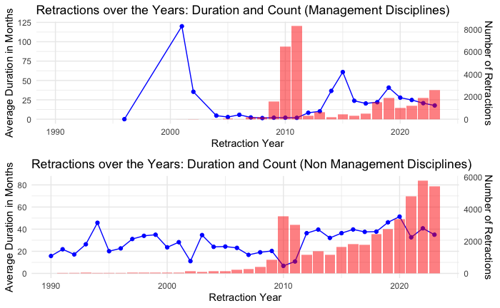

```r
grid.arrange(retractions_management, retractions_nonmanagement, ncol = 1)
```

Trying to understand the distribution of subjects now.

Distribution of Subjects - Non Management Subjects

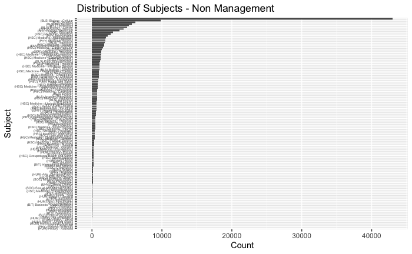

```r
# Separate the subjects into individual rows
data_subjects <- data_nonbusiness %>%
                 separate_rows(subject, sep = ";\\s*")

# Count the occurrences of each subject
subject_count <- data_subjects %>%
                 count(subject, sort = TRUE)

# Create a horizontal bar chart
ggplot(subject_count, aes(y = reorder(subject, n), x = n)) +
    geom_bar(stat = "identity", position = "dodge") +
    theme(axis.text.y = element_text(size = 4)) +
    labs(y = "Subject", x = "Count", title = "Distribution of Subjects - Non Management")
```

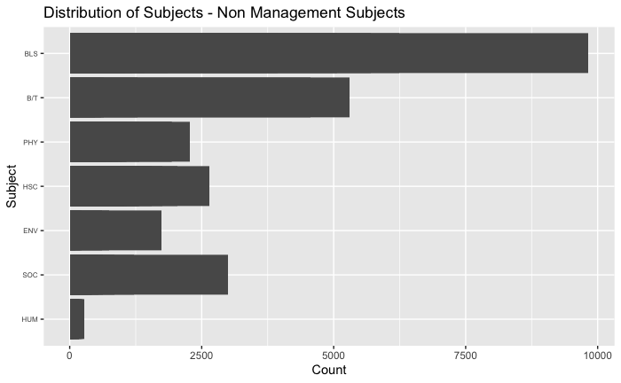

```r
# Rename the subject to the broader theme that's written in the brackets
subject_count <- subject_count %>%
  mutate(subject = str_match(subject, "\\(([^)]+)\\)")[,2])

# Remove NA values that might have been introduced if there were subjects without brackets
subject_count <- subject_count %>%
  filter(!is.na(subject))

# Create a horizontal bar chart
ggplot(subject_count, aes(y = reorder(subject, n), x = n)) +
  geom_bar(stat = "identity", position = "dodge") +
  theme(axis.text.y = element_text(size = 6)) +
  labs(y = "Subject", x = "Count", title = "Distribution of Subjects - Non Management Subjects")
```

Distribution of Subjects - Management Subjects

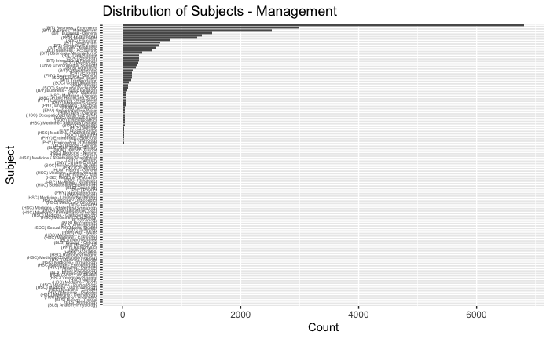

```r
# Separate the subjects into individual rows
data_subjects <- data_business %>%
                 separate_rows(subject, sep = ";\\s*")

# Count the occurrences of each subject
subject_count <- data_subjects %>%
                 count(subject, sort = TRUE)

# Create a horizontal bar chart
ggplot(subject_count, aes(y = reorder(subject, n), x = n)) +
    geom_bar(stat = "identity", position = "dodge") +
    theme(axis.text.y = element_text(size = 4)) +
    labs(y = "Subject", x = "Count", title = "Distribution of Subjects - Management")
```

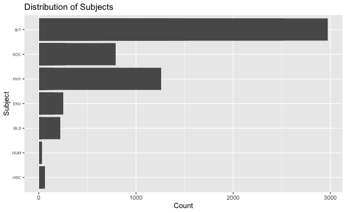

```r
# Rename the subject to the broader theme that's written in the brackets
subject_count <- subject_count %>%
  mutate(subject = str_match(subject, "\\(([^)]+)\\)")[,2])

# Remove NA values that might have been introduced if there were subjects without brackets
subject_count <- subject_count %>%
  filter(!is.na(subject))

# Create a horizontal bar chart
ggplot(subject_count, aes(y = reorder(subject, n), x = n)) +
  geom_bar(stat = "identity", position = "dodge") +
  theme(axis.text.y = element_text(size = 6)) +
  labs(y = "Subject", x = "Count", title = "Distribution of Subjects")
```

Note: You see that there are other non management areas also linked here. That’s because a lot of the papers have also been listed as science, environment and sociology, etc.

Trying to understand the distribution of countries now

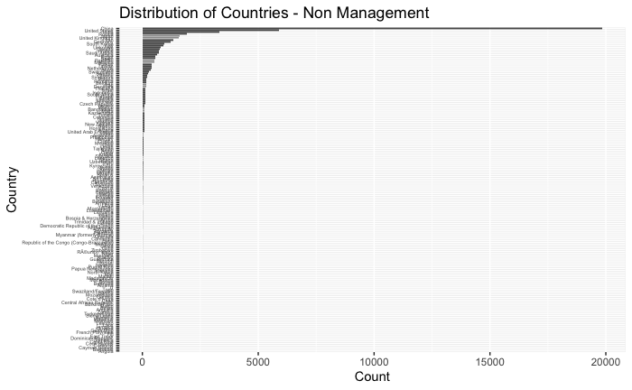

```r
# Separate the subjects into individual rows
data_country <- data_nonbusiness %>%
                 separate_rows(country, sep = ";\\s*")

# Count the occurrences of each subject
country_count <- data_country %>%
                 count(country, sort = TRUE)

# Create a horizontal bar chart
ggplot(country_count, aes(y = reorder(country, n), x = n)) +
    geom_bar(stat = "identity", position = "dodge") +
    theme(axis.text.y = element_text(size = 4)) +
    labs(y = "Country", x = "Count", title = "Distribution of Countries - Non Management")
```

```r
length(unique(country_count$country))
```

```
[1] 173
```

There appear to be authors from 173 countries participating here.

[figure not shown]

```r
# Separate the subjects into individual rows
data_country <- data_business %>%
                 separate_rows(country, sep = ";\\s*")

# Count the occurrences of each subject
country_count <- data_country %>%
                 count(country, sort = TRUE)

# Create a horizontal bar chart
ggplot(country_count, aes(y = reorder(country, n), x = n)) +
    geom_bar(stat = "identity", position = "dodge") +
    theme(axis.text.y = element_text(size = 4)) +
    labs(y = "Country", x = "Count", title = "Distribution of Countries - Non Management")
```

```r
NA
NA
```

```r
length(unique(country_count$country))
```

```
[1] 94
```

There appear to be authors from 94 countries participating here.

Trying to understand the distribution of institutions now

```r
# Separate the subjects into individual rows
data_institution <- data_nonbusiness %>%
                 separate_rows(institution, sep = ";\\s*")

# Count the occurrences of each subject
institution_count <- data_institution %>%
                 count(institution, sort = TRUE)

length(unique(institution_count$institution))
```

```
[1] 77610
```

There appear to be authors from 77610 institutions participated here.

```r
# Separate the subjects into individual rows
data_institution <- data_business %>%
                 separate_rows(institution, sep = ";\\s*")

# Count the occurrences of each subject
institution_count <- data_institution %>%
                 count(institution, sort = TRUE)

length(unique(institution_count$institution))
```

```
[1] 8240
```

There appear to be authors from 8240 institutions participated here.

Checking on repeat offenders

```r
# Separate the subjects into individual rows
data_author <- data_nonbusiness %>%
                 separate_rows(author, sep = ";\\s*")

# Count the occurrences of each subject
author_count <- data_author %>%
                 count(author, sort = TRUE)

author_count_nonbusiness <-author_count

length(unique(author_count$author))
```

```
[1] 122573
```

There are about 1,22,573 unique authors in the non business dataset.

```r
length(unique(author_count$author))/length(data_nonbusiness$record_id)
```

```
[1] 2.850535
```

```r
length(unique(author_count$author))/length(data_nonbusiness$record_id)
```

```
[1] 2.850535
```

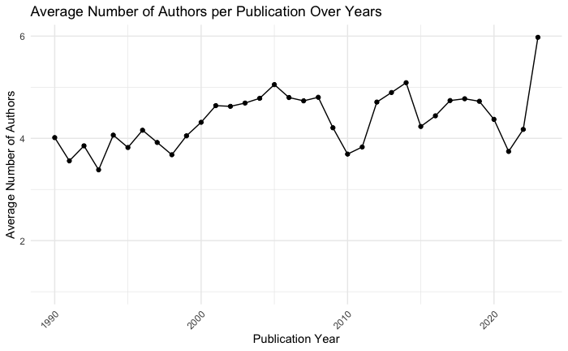

```r
# Step 1: Add a column with the number of authors per publication
data_nonbusiness <- data_nonbusiness %>%
  mutate(
    num_authors = sapply(strsplit(as.character(author), ";"), length),
    publication_year = year(original_paper_date)
  )

# Step 2: Group by publication year and calculate the average number of authors
average_authors_per_year <- data_nonbusiness %>%
  group_by(publication_year) %>%
  summarise(average_authors = mean(num_authors, na.rm = TRUE))

# Plotting the average number of authors per year
ggplot(average_authors_per_year, aes(x = publication_year, y = average_authors)) +
  geom_line() +  # Line plot
  geom_point() + # Adding points to each year
  theme_minimal() +
  labs(
    title = "Average Number of Authors per Publication Over Years",
    x = "Publication Year",
    y = "Average Number of Authors"
  ) +
  theme(
    axis.text.x = element_text(angle = 45, hjust = 1) # Adjusting x-axis labels for better readability
  )+
    scale_x_continuous(limits = c(1990, max(average_authors_per_year$publication_year))) # Limiting x-axis from 1980 onward
```

```r
NA
NA
```

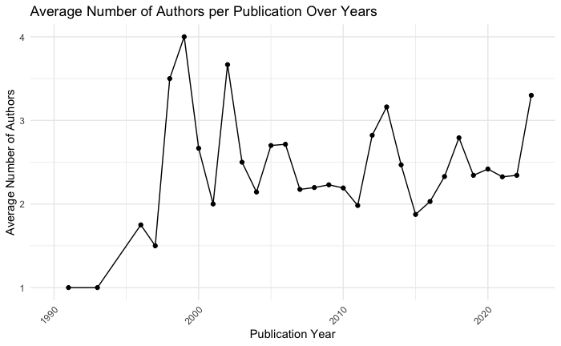

```r
# Step 1: Add a column with the number of authors per publication
data_business <- data_business %>%
  mutate(
    num_authors = sapply(strsplit(as.character(author), ";"), length),
    publication_year = year(original_paper_date)
  )

# Step 2: Group by publication year and calculate the average number of authors
average_authors_per_year <- data_business %>%
  group_by(publication_year) %>%
  summarise(average_authors = mean(num_authors, na.rm = TRUE))

# Plotting the average number of authors per year
ggplot(average_authors_per_year, aes(x = publication_year, y = average_authors)) +
  geom_line() +  # Line plot
  geom_point() + # Adding points to each year
  theme_minimal() +
  labs(
    title = "Average Number of Authors per Publication Over Years",
    x = "Publication Year",
    y = "Average Number of Authors"
  ) +
  theme(
    axis.text.x = element_text(angle = 45, hjust = 1) # Adjusting x-axis labels for better readability
  )+
    scale_x_continuous(limits = c(1990, max(average_authors_per_year$publication_year))) # Limiting x-axis from 1980 onward
```

```r
NA
NA
```

Preparing a joint plot

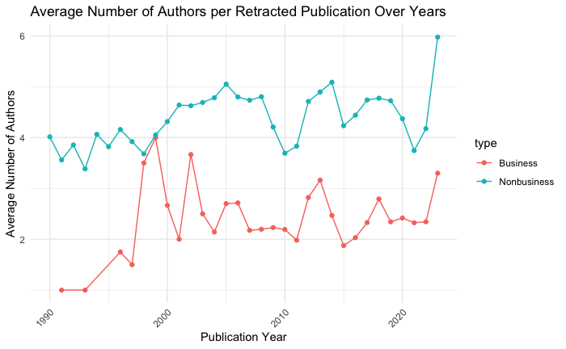

```r
# Prepare nonbusiness data
data_nonbusiness <- data_nonbusiness %>%
  mutate(
    num_authors = sapply(strsplit(as.character(author), ";"), length),
    publication_year = year(original_paper_date),
    type = "Nonbusiness"
  )

# Prepare business data
data_business <- data_business %>%
  mutate(
    num_authors = sapply(strsplit(as.character(author), ";"), length),
    publication_year = year(original_paper_date),
    type = "Business"
  )

# Combine the datasets
combined_data <- bind_rows(data_nonbusiness, data_business)

# Group by publication year and type, then calculate the average number of authors
average_authors_per_year_type <- combined_data %>%
  group_by(publication_year, type) %>%
  summarise(average_authors = mean(num_authors, na.rm = TRUE))
# Plotting the average number of authors per year for both types
ggplot(average_authors_per_year_type, aes(x = publication_year, y = average_authors, color = type)) +
  geom_line() +  # Line plot
  geom_point() + # Adding points to each year
  theme_minimal() +
  labs(
    title = "Average Number of Authors per Retracted Publication Over Years",
    x = "Publication Year",
    y = "Average Number of Authors"
  ) +
  theme(
    axis.text.x = element_text(angle = 45, hjust = 1) # Adjusting x-axis labels for better readability
  )+
  scale_x_continuous(limits = c(1990, max(average_authors_per_year_type$publication_year))) #
```

From this, it does look like management related publications (as classified by the authors) does not seem to have as many authors as non management related articles.

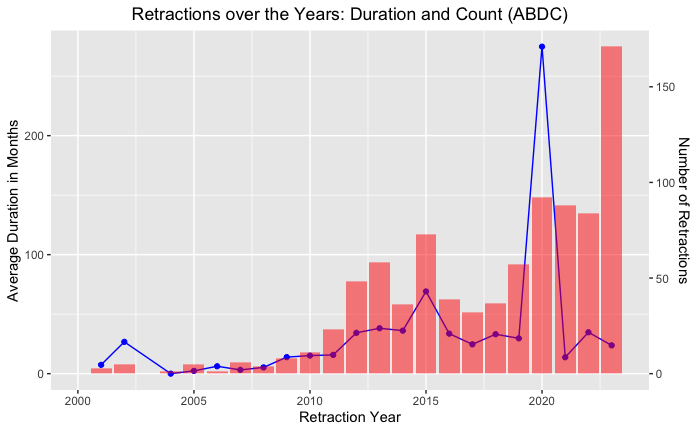

```r
# Prepare data
yearly_data <- ret_int_abdc %>%
  group_by(retraction_year) %>%
  summarize(average_duration = mean(duration_in_months, na.rm = TRUE),
            retraction_count = n())

# Normalize the RetractionCount for better visualization
max_duration <- max(yearly_data$average_duration, na.rm = TRUE)
max_count <- max(yearly_data$retraction_count, na.rm = TRUE)
yearly_data$NormalizedCount <- yearly_data$retraction_count / max_count * max_duration

retractions_management<- ggplot(yearly_data, aes(x = retraction_year)) +
  geom_line(aes(y = average_duration, group = 1), color = "blue") +
  geom_point(aes(y = average_duration), color = "blue") +
  geom_bar(aes(y = NormalizedCount), stat = "identity", fill = "red", alpha = 0.5) +
    scale_x_continuous(limits = c(2000, NA)) +

  scale_y_continuous(name = "Average Duration in Months",
                     sec.axis = sec_axis(~ . * max_count / max_duration,
                                         name = "Number of Retractions")) +
  labs(title = "Retractions over the Years: Duration and Count (ABDC)",
       x = "Retraction Year") +
  theme(
    plot.title = element_text(hjust = 0.5),  # Center-align the title
    plot.subtitle = element_text(hjust = 0.5),  # Center-align the subtitle if you have one
    axis.title.x = element_text(hjust = 0.5)  # Center-align the x-axis label
  )


retractions_management
```

From this data set, let’s try to pull out the names of every author.. and see if there are 1. repeat offenders 2. How many total authors are there with retraction related issues

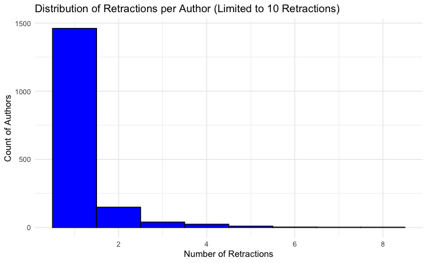

```r
# Expand the dataset so each row represents a record-author combination
expanded_dataset <- ret_int_abdc %>%
  separate_rows(author, sep = ";") %>%
  mutate(author = trimws(author))  # Remove any leading/trailing whitespace

# Count the number of retractions for each author
author_retraction_counts <- expanded_dataset %>%
  group_by(author) %>%
  summarise(retraction_count = n()) %>%
  filter(author != "")  # Remove empty author entries if any


# Define a threshold for the maximum number of retractions per author
threshold = 10  # Adjust this number based on your data and needs

# Filter the data to exclude outliers
filtered_author_retraction_counts <- author_retraction_counts %>%
  filter(retraction_count <= threshold)

ggplot(filtered_author_retraction_counts, aes(x = retraction_count)) +
geom_histogram(binwidth = 1, fill = "blue", color = "black") +
labs(title = paste("Distribution of Retractions per Author (Limited to", threshold, "Retractions)"),
x = "Number of Retractions",
y = "Count of Authors") +
theme_minimal()
```

```r
NA
NA
```

## Let’s try to create an author author relationship network.

But that’s not possible to do with the limited data that we have access to at the moment. We are going to have to explore who all the authors have linked up with in the past aswell.

One of the issues that becomes increasingly apparent is the nationality of the retractions. It appears that many of the retractions stem from nations like China.

Let me show you.

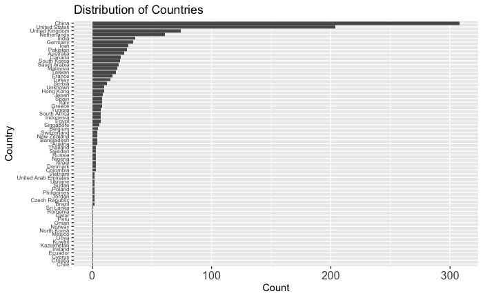

```r
# Ensure the 'country' column is a character vector if it is not already
our_interest <- ret_int_abdc %>%
  mutate(country = as.character(country))

# Assuming 'country' is a column where countries are separated by semicolons (and possibly followed by spaces)
data_country <- our_interest %>%
  separate_rows(country, sep = ";\\s*") # sep regex matches a semicolon followed by any number of spaces

# Count the occurrences of each country
country_count <- data_country %>%
  count(country, sort = TRUE)

# Create a horizontal bar chart
ggplot(country_count, aes(x = reorder(country, n), y = n)) +
  geom_bar(stat = "identity") +
  coord_flip() +  # Flip the coordinates to make the bars horizontal
  theme(axis.text.x = element_text(size = 12),axis.text.y = element_text(size = 6)) +  # Adjust the size if needed
  labs(x = "Country", y = "Count", title = "Distribution of Countries")
```

it looks like China, US, UK, Netherlands and India are the key sources of retractions.

Can in be that this is a problem is located to within certain countries? or is this a truly corss cultural issue?

Creating retraaction-author-author network

```r
# Create a data frame where each row represents a single author for a given record_id
author_records <- our_interest %>%
  separate_rows(author, sep = ";") %>%
  distinct(record_id, author)

# Create a square matrix of authors, initialized to zero
unique_authors <- sort(unique(author_records$author))
coauthor_retraction_matrix <- matrix(0, nrow = length(unique_authors), ncol = length(unique_authors),
                        dimnames = list(unique_authors, unique_authors))

# Fill the matrix with 1's where authors share a record_id
for (i in seq_len(nrow(author_records))) {
  for (j in seq_len(nrow(author_records))) {
    if (author_records$record_id[i] == author_records$record_id[j]) {
      coauthor_retraction_matrix[author_records$author[i], author_records$author[j]] <- 1
    }
  }
}

# Remove self-loops if desired (authors compared with themselves)
diag(coauthor_retraction_matrix) <- 0
```

Generating list of unique authors

```r
authors_list_1 <- expanded_dataset %>%
  select(author) %>%
  unique()

write.csv(authors_list_1, "authors_list.csv")
```

```r
# Load necessary libraries
library(rvest)
library(httr)

# URL of the Google Scholar profile
url <- "https://scholar.google.com/citations?user=rq48Nj8AAAAJ&hl=en&oi=ao"

# Read the web page
page <- read_html(url)

# Extract author name and affiliation
author_name <- page %>% html_node("#gsc_prf_in") %>% html_text()
affiliation <- page %>% html_node(".gsc_prf_il") %>% html_text()
interests <- page %>% html_nodes(".gsc_prf_inta gs_ibl") %>% html_text()
total_citations <- page %>% html_node("#gsc_rsb_st td.gsc_rsb_std") %>% html_text()
co_authors <- page %>% html_nodes("#gsc_rsb_co a") %>% html_text()
education_details <- page %>% html_nodes("css-selector-for-education") %>% html_text()
total_papers <- page %>% html_nodes("#gsc_a_nn") %>% html_text()

# Print the results
print(paste("Author Name:", author_name))
print(paste("Affiliation:", affiliation))
print(paste("Interests:", paste(interests, collapse = ", ")))
print(paste("Total Citations:", total_citations))
print(paste("Co-Authors:", paste(co_authors, collapse = ", ")))
print(paste("Education Details:", paste(education_details, collapse = ", ")))
print(paste("Total Number of Papers:", total_papers))
```

Creating author-publisher network

```r
# Splitting the author field as there could be multiple authors per record
author_split <- expanded_dataset %>%
  separate_rows(author, sep = ";") %>%
  distinct(record_id, author, publisher)

# Creating a list of unique authors
unique_authors <- sort(unique(author_split$author))

# Creating an empty matrix to store the connections
author_publisher_matrix <- matrix(0, nrow = length(unique_authors), ncol = length(unique_authors))
rownames(author_publisher_matrix) <- unique_authors
colnames(author_publisher_matrix) <- unique_authors

# Filling the matrix
for (i in 1:length(unique_authors)) {
  for (j in 1:length(unique_authors)) {
    if (i != j) {
      # Check if authors i and j have published with the same publisher
      common_publishers <- intersect(author_split$publisher[author_split$author == unique_authors[i]],
                                     author_split$publisher[author_split$author == unique_authors[j]])
      if (length(common_publishers) > 0) {
        author_publisher_matrix[i, j] <- 1
        author_publisher_matrix[j, i] <- 1 # Matrix is symmetric
      }
    }
  }
}
```